# Exposure to High Ultra-processed Food and Sodium Intake and its effect on Hypertension from a Cross-sectional study UK National Dietary and Nutritional Survey (NDNS) in England 2008-2019

# Exposure to High Ultra-processed Food and Sodium Intake and its effect on Hypertension from a cross sectional study UK National Dietary and Nutritional Survey (NDNS) in England 2008-2019

# David O’Hagan

200299857

## Dissertation submitted in partial fulfilment of the requirements for the degree of Master of Public Health, The University of Liverpool

## August 2023

no portion of this work has been submitted in support of an application  
for degree or qualification of this or any other University or institute of learning.  
Signature

## Dedication

To Julie, Andrew and Sophie

for your loving patience and support

# Abstract

Hypertension is associated with exposure to high intake of ‘industrially produced edible substances’ or UPF, and high Sodium intake. This research examines assumptions about salt and UPF. Is Sodium the sole cause of this ‘unhealthiness’? Will ‘reformulation’ for Sodium generate ‘healthy UPF’? Can this help reduce BP in one part of the UK?

### 0.0.1 Method

Cross-sectional data with a stratified sample representative of the UK population is used. Data from the National Dietary and Nutrition Survey (NDNS 2008-2019) is analysed.

Multivariable logistic regression is used for analysis of high Sodium intake and high UPF intake against hypertension. Secondary end points included univariable regression of Sodium intake against UPF intake, and age against BP, Sodium intake and UPF intake.

### 0.0.2 Results

There was an increased odds ratio of hypertension with higher Sodium intake (OR=5.57(1.47,21.2)).

There was a lower odds ratio of hypertension with high UPF intake (OR=0.57(0.34,0.94)).

There is a strong correlation between age and BP (beta =0.43 (CI 0.41,0.45)), as well as age and Sodium intake (beta =1.5 (CI 0.77,2.3)).

There is a strong negative age gradient of UPF intake (beta= -0.25 (CI -0.26,-0.23)).

### 0.0.3 Conclusion

This study shows that high Sodium intake is associated with hypertension. Reduction of Sodium intake may be effective at reducing the overall risk of hypertension.

UPF intake shows negative correlation with hypertension, which may be ‘reverse causation’ in this cross-sectional study.

Policy should aim to reduce intake of Sodium. Longitudinal studies may be more effective at identifying the causal relationship between UPF and BP.

Generalising this result, reformulation for low salt would not eliminate the risk of hypertension. Public health policy will need to reduce UPF, not simply reformulate.

### 0.0.4 Keywords

UPF, Sodium, hypertension, reformulation, Nutrition

**Abstract** 296 words

**Dissertation** 9676

## Acknowledgments

This dissertation has come about through the hard work of Zoe and Martin. Their clear vision has been turned upside down and back to front, by my contorted logic and confused ideas. That it is in any way coherent is entirely down to their support, comments and intervention.

The positivity and welcoming engagement has been refreshing for this old cynic. It has been such a pleasure that I almost regret coming to the end.

Thanks to Paul for the project which didn’t quite come together

Table of Abbreviations used

| Abbreviation | Term |
| --- | --- |
| AIC | Akaike Information Criterion |
| BMI | Body Mass Index |
| BP | Blood Pressure |
| CI | Confidence intervals 95% level |
| CHAMPs | Cheshire and Merseyside public health collaborative |
| CVD | Cardiovascular Disease |
| HR | Hazard ratio |
| IMD | Index of Multiple Deprivation |
| Na | Sodium intake in mg |
| NCD | Non communicable Disease |
| NDNS | National Dietary and Nutrition Survey |
| NOVA | NOVA is a classification system, it is not an acronym |
| OR | Odds Ratio |
| UPF | Ultra Processed Foods |

# 1 Introduction

417482 people, 15.4% of the population, have hypertension in Cheshire and Merseyside (1). Cheshire and Merseyside public health collaborative (CHAMPs) have a plan to reduce blood pressure (BP) by 2029 (2) . The strategy aims to increase ‘awareness’. This is intended to increase individual compliance with testing and treatment of hypertension (BP >140). This study intends to offer additional opportunities for improving outcomes.

Nutrition has long been identified as a contributor to hypertension and so non communicable disease (NCD). Sodium is known to be important in the physiology of BP and so is a key target of drug treatment as Rang and Dale (3) describe. Monteiro in 2010 (4) argues that there is more to food than its food group, or identified macro/micro nutrients. He identifies this epidemologically demonstrating that the sum of effects identified from breaking food up into its constituents leaves a gap in the overall effect. This gap he calls ‘processing’. His initial three part food classification was not conclusive, but demonstrated better matching when the ‘processed food’ category was divided in two (5) . The new category ‘Ultra-processed’ (UPF) has caused controversy since, but has proven to be effective for study, and discussion.

UPF makes up up to 60% diet in UK especially in the North West of England. There is evidence of an association between hypertension and intake of Ultra-processed Foods (UPF) (6) (7) (8) (9) and hypertension and Salt intake (10) (11) (12) (13) (14) from studies of different types in multiple countries. Moreira et al (15) model a scenario where “halving intake of (NOVA) group 3 foods could result in approximately 22,055 fewer deaths” across the UK in 2030.

This might explain why food strategy, such as in Liverpool (16), can make a significant public health impact. Byker-Shanks (17) identify the effect of policy reducing UPF intake, potentially reducing hypertension at a population level.

This analysis considered exposure to Sodium and UPF, and prevalance of hypertension using a nationally representative cross-sectional study, the National Dietary and Nutrition Survey (NDNS) (18) . This study has data from the UK from 2008 to 2019. It is stratified to be representative of the population of the UK by sex, age, region and index of multiple deprivation (IMD). BP, UPF and Sodium intake were recorded, with age and sex as important background factors.

I have used STROBE guidance (19) in producing this report. This study explored this complex web pulling out strands within it, diagram 1 shows a possible arrangement of this.

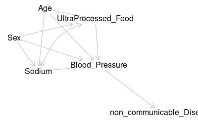

## 1.1 Epistemology

The epistemological approach of this study is positivist. I use a quantitative approach in a mechanistic and deterministic model. However, I am aware that this model is incomplete. Using this lens UPF might be identified as comprising of aspects outside a purely biological nutrition model, though it has enough complexity even within its positivist aspects.

Dietary change requires understanding interaction with cultural,social and economic factors, not positivist experimental isolation. Critical realist and social constructionist research complements this research. Dahlgren and Whitehead’s (20) (21) (22) commercial and social determinants of health are models which have a great deal to add to understanding the impact of exposure to UPF and Sodium, and of dietary effects on BP.

## 1.2 Positionality

Food, and diet have constructivist aspects. Hence, the observer cannot be isolated from their experiment. My positionality, therefore, is of interest. Jafar (23) argues that understanding the position of the investigator is of interest to understanding quantitative study as well as qualitative study.

Positivist ideals match from my biomedical background. Illich (24) is one of many who have identified that medicine was never about science. Foucault (25) is clear that medicine is not a simple biologic scientific relationship. As an older physician I am aware, that social factors impact health of participants as Evans and Trotter (26) also discuss.

I also understand that my perception of the world is from a position of significant privilege. I have resources and knowledge which make my position atypical. In proceeding, I must be aware of the limitations of the positivist approach, and of this atypical view of the world.

Ideas, social expectations, income, or geography affect food and health ‘choices’. They also impact on ‘hard’ clinical measurements such as BP, through physical position and room temperature as well as by the relationship between the observer and the participant.

This work is primarily to complete requirements for an MPH degree which means that it is influenced by factors around health equity and classic epidemiology as taught on the course. It is produced in collaboration with a research group with a long established reputation in food research in public health, which may steer the results in a conservative direction.

# 2 Literature Review

## 2.1 Rationale

This systematic search, aims to identify papers with information about UPF, Sodium and blood pressure informed by PRISMA (27).

The rationale for this review is to contribute background and to answering the research question;

What is the evidence that in adults and children across the four home nations of the UK between 2008 and 2019, would exposure to high Sodium dietary intake, and or high UPF dietary intake, compared to lower exposure, increase the odds of having a mean systolic blood pressure of over 140mmHg?

## 2.2 Method

Eligible studies were cross-sectional studies, and systematic reviews considering the relationship between the exposure, and outcome in comparable general populations. Papers were excluded where the population was specifically of one type, or had a specified health condition. Another exclusion criterion was where specific foods were considered.

Scopus (28) , Pubmed , Web of Science and Medline(ovid) (29) were searched. Grey literature, especially government reports around NDNS were studied. This identified a report from SACN (30) . The Cochrane database of systematic reviews was accessed but no additional reviews were found.

The search strategy is included in table 1 below. The search concentrated on systematic reviews, these identified high quality primary research. Other sources were identified by cross referencing bibliographies particularly from the systematic reviews. Colleagues identified further relevant literature.

My search terms

Description of Search

[output not shown]

## 2.3 Selection strategy

Inclusions and exclusions are identified in the table. No time limits, language limits or availability limits were included in the search.

The papers were reviewed by the author only.

The data sought were odds ratios for the effect of UPF or Sodium on blood pressure and outcomes of systematic reviews.

There is risk of bias due to the single reviewer approach.

There is some heterogeneity of approach to reporting exposure or outcome making it difficult to compare items directly.

## 2.4 Search results

The search identified 593 papers, 348 after removing duplicates. Chart 1 shows how these were assessed.

[interactive chart not shown]

These were then reviewed by comparing the titles against the inclusion and exclusion criteria leaving 56. 6 systematic reviews were identified, one which considered both UPF and Sodium intake. Some of these calculated odds ratios using meta-analysis. The SACN report identified papers within its broader remit.

## 2.5 Discussion of literature

Systematic reviews and Meta-analyses

| First Author | Type of Study | Subject of Study | Results |
| --- | --- | --- | --- |
| Barbosa (31) | systematic review Papers from Americas | UPF and Sodium and Hypertension | 5 cross-sectional and 4 cohort studies +ve association found |
| Wang (32) | systematic review and meta analysis | UPF and hypertension | 5 cross-sectional and 4 cohort studies (odds ratio: 1.23; 95% CI: 1.11, 1.37; P=0.034) |
| Mambrini (9) | systematic review few studies one women only study | UPF and BP | 4/17 UPF and BP +ve association found |
| D’Elia (33) | meta-analysis | Salt and CVD | 11 studies *a 2.84% (95% CI 0.51–5.08) reduction in PWV* |
| Leyvraz (34) | meta-analysis children | Sodium blood pressure | 13/18 studies every additional gram of Sodium intake per day, systolic blood pressure increased by 0.8 mmHg (95% CI: 0.4, 1.3) |
| Frias (35) | systematic review of cohorts children | Sodium and BP | 2 studies BP no association systolic BP |
|  | nb BP is Blood Pressure | nb CI is confidence interval | nb CVD is cardiovascular disease UPF is Ultraprocessed food |

### 2.5.1 UPF and BP

Three systematic reviews, those of Mambrini et al (9) ,Barbosa et al (8) , and Wang et al (7) highlight the risk of hypertension with high UPF. They also identify that the effect is not always evident. Wang’s meta-analysis was used to calculate the sample size for this study. All these reviews appeared of good quality following guidance. Mambrini and Barbosa were restricted to a narrative description of the results, both identified broader cardiovascular outcomes. They identified heterogeneity in definitions of UPF and of differences in populations as a difficulty for comparison.

Mambrini et al, in their systematic review, identify that few papers attempt to link UPF with hypertension. They identify a positive correlation. Their systematic review identifies Monge et al (36) , Scaranni (37) , and Mendonça (38) , whose three cohort studies of middle aged adults were followed up for between 2.2 and 9.1 years. This was a well described study which appears to comply with best guidance for systemic review.

Scaranni used Brazil’s ELSA study, in middle aged civil servants, finding that higher UPF had a marginally greater risk of developing hypertension (OR = 1.17; 95% CI: 1.00, 1.37) compared with lower intake. They measured Sodium 24 hour urinary excretion, but found no difference between UPF consumption groups. They include Sodium in some multivariable models, but the discussion only considers the general cases ‘UPF is high in Sodium’ and ‘People in Brazil eat lots of UPF’.

Monge found no association between categories of UPF, from ≤20% to >45% energy/day and incident hypertension. This study used mexican female teachers, this group may have a different exposure and outcome profile to a more general population. Sodium intake showed no difference across UPF groups, they made no comment on how it might relate to hypertension or UPF consumption.

Mendonça in Spain found an affect on hypertension (HR = 1.21, 95% CI: 1.06, 1.37, Ptrend = 0.004) in adults. This sample had a strong effect on Wang’s meta analysis with a weighting of 16.72 from 9 studies. Mendonça identified that young men have high UPF intakes, and young men have high Sodium intakes based on reports of their diet. Their Sodium intake values were adjusted for total energy intake. Their key finding was that the same tertile for UPF intake also had a raised BP also had a raised Sodium intake. Having adjusted for energy they did not include it in their multi-variate analysis.

Of these studies, the study by Nasreddine was a very small localised study, as shown by the wide confidence interval. Monge and Lavigne-Robichaud also had equivocal results. Lavigne-Robichaud’s sample was a very specific sub-population in Canada and Sodium is mentioned only briefly.

Barbosa identified a different group of studies. No meta-analysis was done. The studies included a wider range of outcomes making it hard to compare results. The narrative outcome was a similar positive correlation.

Da Conceição (45) (n= 64) states that individuals with higher minimally processed diet had higher sodium intakes, but there was no association of hypertension with UPF . Martinez-Peres (46) (n=5636) found no statistical significant change in BP with UPF and considered Sodium only in comparison across other classification systems. Martinez-Steele (47) (n=6385) bundled BP in with metabolic syndrome and did not consider Sodium. Smiljanec (48) (n=40) demonstrated that Sodium intake was higher with UPF than moderately processed food (MPF) and uniquely that BP changes were statistically significant in females not males.

Shim (49) demonstrated the effect on hypertension in Korea, despite the highest tertile percentage UPF being only >28.55% much less than in European and US studies. Sodium was discussed, but not measured or used in analysis.

Table of papers on UPF and BP

| First Author | Study Type | Subject | Results |
| --- | --- | --- | --- |
| Shim (50) | Korean Cross-sectional | UPF and Hypertension | OR= 1.25,CI: 1.11 and 1.40 |
| Scaranni (37) | Brazil ELSA cohort | UPF and Hypertension | OR = 1.17; 95% CI: 1.00, 1.37 |
| Rezendez-Alves (44) | Brazil cohort | UPF and Hypertension | RR: 1.35; 95% CI: 1.01, 1.82). |
| Martinez-Peres (46) | Spain Transverse | UPF and BP | no significant effect |
| Monge (36) | Mexico women only Cohort | UPF and BP | no effect |
| da Conceicao (45) | Cross-sectional | UPF and BP | no effect |
| Nardocci (42) | Canada Cross-sectional | UPF and hypertension | OR = 1.60, 95% CI: 1.26–2.03) |
| Nasreddine (43) | Lebanese Cross-sectional | UPF and BP | OR 3.10 (0.58,16.66) |
| Lavigne-Robichaud (40) | Canada Cree People Cross-sectional | UPF and BP | 0.99 (0.59,1.68) |
| Martinez-Steele (41) | USA Cross-sectional | UPF and Mets | 1.19(1.03,1.38) |
| Smiljanec (48) | USA Cross-sectional | UPF and BP | Positive association between UPFs and general SBP (B = 0.25, 95% CI: 0.03, 0.46, p = 0.029) |
| Ivancovsky-Wajcman (39) | USA Cross-sectional | UPF and BP | OR = 1.53, 1.07- 2.19, P = .026 |
| de Deus Mendonça (38) | Spain cohort middle aged uni grads | UPF and (self -reported) hypertension | HR, 1.21; 95% CI, 1.06, 1.37; P for trend = 0.004 |
| nb HR is hazard ratio RR is relative risk | nb BP is Blood Pressure OR is Odds ratio | nb CI is confidence interval | nb CVD is cardiovascular disease UPF is Ultraprocessed food |

### 2.5.2 Salt and CVD

Review papers Sodium and BP

| First Author | Study Type | Subject | Results |
| --- | --- | --- | --- |
| He (51) | meta-analysis Adults some with hypertension | Salt and hypertension | 11 trials in ‘normotensive’ 17 in ‘hypertensive’ A reduction of 100 mmol/day (6 g of salt) in salt intake predicted a fall in systolic blood pressure of … 3.57 mmHg in normotensive individuals (systol… |
| Strazzullo (12) | meta-analysis | Salt and CVD | 13 studies risk of stroke (pooled relative risk higher salt intake 1.23, 95% confidence interval 1.06 to 1.43; P=0.007) and cardiovascular disease (1.14, 0.99 to 1.32; P=0.07) |
| Graudal (13) | meta-analysis Adults | Salt and CVD | 23 prospective cohort studies *ACM: HR = 1.16, 95% CI = 1.03-1.30; CVDEs: HR = 1.12, 95% CI = 1.02-1.24* |
| Ma (14) | meta-analysis Healthy adults | urinary Sodium and CVD | 6 prospective studies Each daily increment of 1000 mg in Sodium excretion was associated with an 18% increase in cardiovascular risk (hazard ratio, 1.18; 95% CI, 1.08 to 1.29), |
|  | nb BP is Blood Pressure | nb CI is confidence interval | nb CVD is cardiovascular disease nb UPF is Ultraprocessed food |

The systematic reviews identified in the search include Barbosa (8) , and D’Elia (33) . Leyvraz (34) and Frias (35) concentrate on effects in children where the effects were equivocal. These reviews appeared of good quality with appropriate inclusion and exclusion criteria.

He (11) , Graudal (13) and Strazzullo (12) were not identified in this search but were referenced in the other papers.

Graudal et al. Studied cohort studies as there were no RCTs of increased Sodium intake. They found data from 23 cohort studies (n=274,683). They showed all cause mortality (ACM) and cerebrovascular events (CVDE) were increased in high Sodium intake compared with usual Sodium intake *(ACM: HR = 1.16, 95% CI = 1.03-1.30; CVDEs: HR = 1.12, 95% CI = 1.02-1.24)*.

Their findings identify that there might be ‘too much’ salt reduction possible. They provide an explanation as to how low Sodium levels may causes issues.

D’Elia et al (33) , in their systematic review, look at arterial stiffness pressure wave velocity (PWV) and show that this increases with salt intake. This arterial stiffness is potentially more sensitive to Sodium intake than BP. They included 11 studies, of 14 cohorts and 431 participants studied over 1-6 weeks. Reducing Sodium intake by 89.3mmol/day was associated with 2.84% (CI0.51-5.08) reduction in PWV.

D’Elia’s results show that BP is less accurately predicted than arterial stiffness. This may be a cause of the equivocal results found by studies looking at BP.

Straluzzo et al identified 19 cohort samples, with 117025 participants followed for 3.5-19 years, resulting in over 11000 vascular events. Identifying small, but statistically significant relative risk values.

Ma et al (14) studied 24 hour Sodium excretion. This is more reliable than reported intake, or intake calculated from food values. Their older group was studied for 8.8 years. An increase of 1000 mg/day in Sodium excretion was associated with an 18% increase in cardiovascular risk (hazard ratio, 1.18; 95% CI, 1.08 to 1.29).

These papers agree that Sodium intake is associated with increased BP and cardiovascular issues. They show an odds ratio for CVD with raised Sodium intake and hypertension with high UPF intake. They suggests BP is an uncertain outcome measurement. Papers often look to CVD outcomes as stronger endpoints.

## 2.6 Literature review Conclusion

These studies rarely reported on Sodium, and never tried to understand how the relationship between Sodium UPF and hypertension might work.

Of the identified papers there is little evidence to back up the often repeated conjecture that increased Sodium intake simple follows from increased UPF intake, and that this is the mechanism by which UPF ‘causes’ hypertension. This is the gap in the literature which the current is intended to address.

The papers looking at Sodium and hypertension identify a significant effect. They often report broader outcome measures and alternative methods of assessing hypertension as being more representative or reproducible.

The relationship between these two effects, UPF and Sodium, can be shown by studying both in the same population. This research aims to identify these two effects at the same time within a large representative cross-sectional population thereby answering this gap. This study also gives the opportunity to consider if there are associated factors and to understand the public health implications in response to the challenge set by SACN’s statement on processed foods and health (30) .

## 2.7 Research Question

Using PICO (52) approach,

In adults and children across the four home nations of the UK between 2008 and 2019, how much exposure to high Sodium dietary intake, and or high UPF dietary intake, compared to lower exposure, increased the odds of having a mean systolic blood pressure of over 140mmHg?

In addition it may be possible to consider, if there is evidence of interaction between these and is UPF or Sodium most important in these changes?

## 2.8 Objectives

1 Literature Review of UPF and BP, and Sodium and BP

2 Descriptive analysis of participants from NDNS with amalgamation of data across the rolling programme.

3 Analysis of exposure to UPF and Sodium, and prevalence of hypertension (BP >140mmHg) using regression models with associated data analysis.

4 Discussion of implications of results in answer to the research question, Public health implications and actions. Also in relation to limitations of cross- sectional studies, and available data, as well as suggestions for further research

# 3 Method

## 3.1 Study Setting and Design

This analysis intends to analyse the association between Sodium intake, UPF intake and BP. This is secondary data analysis of national cross-sectional data from the National Dietary and Nutritional Survey (NDNS (18)).

NDNS was commissioned in collaboration between government departments responsible for health and for food production. Academic partners delivered reports on diet and nutrition across the United Kingdom. The study is designed to be representative across the four home nations, and across age with balanced representation for children. NDNS data are available via the UK National Data Service for research purposes.

NDNS is a rolling cross-sectional study, in each year a new cross section of participants is enrolled from the wider population. Questionnaires, food diaries, and nurse assessments are used to gather data. It has been running since 2008. The most recent data is available from 2019. This is a rich resource with data on exposures and outcomes and explanatory variables.

## 3.2 University Research Governance and Ethical Review

The storage of the data is in keeping with the research governance agreements of the University and the Data set owners.

## 3.3 Participants, Inclusion and Exclusion

Participants were identified by random selection across postal units. The sample is stratified to ensure a representative sample across the four nations (England, Wales, Scotland, and Northern Ireland) and across regions in England (North, Central/Midlands, South(including London)). The sample is also stratified for age and sex and Index of multiple deprivation (IMD). Invitiations were sent out to households across the four nations. Participants who agreed to take part were visited by a research nurse. Participants gave informed consent and were able to withdraw consent at any time, the study was conducted within ethics committee guidance.

For NDNS the intended sample is 1000 per year with 50% adults. Each year the sample is slightly different due to differential uptake. Oversampling is used to control this.

The relationship between salt and systolic blood pressure may be different in individuals with pathologically high BP. Those taking BP controlling medications may have a different relationship to Sodium and UPF and so were excluded for analysis.

## 3.4 Exposure Variables

The participants recorded their food intake as a food diary. Four days of the diary including a weekend day are used for each participant. They record food and portion size as well as where food was eaten. Other information is collected by a structured interview, and by clinical assessment by a research nurse. The consent, interview and diary documents are available within the NDNS dataset.

The NDNS analysis team use the the food and drink intake reported. The food reported is entered into a growing database which has details of constituent nutrients. The foods are divided into food groups and in the last three years some more analysis of how constituents of dishes are assembled. That is a dish might be examined as a ‘stew’ in the past, but more recently be described as meat, and ‘stew mix’ or meat and potatoes and onion and celery.

### 3.4.1 Sodium estimation

This analysis used the daily Sodium intake in mg from NDNS. This value reflects the expected content of standard foods calculated from the diary entry.

24 urinary Sodium is considered the best indicator of dietary Sodium but values are not available across the whole time period. Serum Sodium values are available for the early dataset, but not the later one. Each of these values has slightly diffeernt patterns in relation to quantities ingested. Some of these differences may reflect polymorphism in physiological handling of Sodium, and this might reflect some salt sensitivity syndromes.

WHO recommended Sodium intake is less than 3000mg Sodium. Du et al (6) used categories of moderate and high intake at 5000mg and 6000mg, these categories were used for Sodium in this research.

### 3.4.2 UPF

The NOVA classification, developed by Monteiro et al. (5), was used to estimate the intake of UPF. There is no record of NOVA classification in NDNS. This data was developed by comparing every food level entry in NDNS against NOVA. A standard methodology describing the approach used has been published by Martinez-Steele et al. (47) .

The energy content of the day’s food was calculated by NOVA group. This was added to the intake for the other 3 days and the total intake by NOVA group established. The percentage of the total intake of energy was then calculated for each of the 4 Nova categories. Nova group 4 or UPF intake (UPF) is used for this study, this dataset was provided by Dr Colombet (personal communication).

Categories of UPF intake used in other papers eg Wang (53) are low for the UK. Centre-weighted categories were used. The central category is the mean with one standard deviation above and below. This effectively identifies 67% in the centre of the distribution.

## 3.5 Outcome Variable

BP is a quality assured mean systolic BP which is reliable across the dataset. It was measured in mmHg using a calibrated automatic sphygmomanometer by a study nurse under specified conditions. These conditions controlled for the effects of exercise, temperature and ill health. The data on all these is in the dataset. Raw BP values are also present in the dataset to allow quality review.

Other studies have used ambulatory BP, or Pulse Wave Velocity (PWV) to assess the effect of UPF and Sodium on the body. There is a much longer history and literature around the effect of clinician administered measurements. Many studies use patient reported diagnosis or clinician diagnosis, or even evidence of treatment to identify hypertensive participants. In this research only the measured values have been used, and participants on medication affecting the BP have been excluded from the analysis.

Hypertension is BP over 140 mmHg, categorised to enable logistic regression. This value is identified by Du et al ((6)) and others, though some use lower values such as 120mmHg ( (49) )

## 3.6 Other Variables

Additional explanatory variables are ones which can also influence BP. They include age, sex, and BMI. Age at completion of education , and IMD are also used. These may have effects such as confounding, mediation, and obstruction within the analysis.

Stratification is used in the design and sampling stage to modify for these. Including them in multivariable regression attempts to prevent them confounding the analysis.

Age is used as continuous and categorised data for the analysis. It has a complex role in cross-sectional analysis.This will be considered in the discussion. Stratification ensures a large enough sample with 50/50 children and adults.

The sex of participants is identified, as an important explanatory variable. I have not analysed women separately from men, as Criado-Perez (54) requests. There are single sex studies. These identify that reporting, diet, and effects all follow different patterns in men and women. My reason is to maintain sample size, but the significant differences in physiology are clearly important.

Body Mass Index (BMI) is identified as a potential explanatory variable. It is a calculated variable based on weight and height. There is also a known association with BP. Preliminary analysis was performed with weight and height separately, there was no additional information gained.

Index of Multiple Deprivation (IMD) is included to identify socio-economic patterns in the data. This UK based data is used consistently in UK studies, but has no analogue internationally. It is calculated at nation level with a different value for England, Wales, Scotland and Northern Ireland and a different update frequency. The index is built of scores for a small locality (lower-layer super output areas). The deprivations relate to income, employment, education, health, crime, housing and living environment. Including it does to some extent duplicate the effect of health deprivation on the analysis.

Internationally age at completion of education, or income are often used. Income data is reported inconsistently through the survey years and so is not used in this analysis. Age at leaving education is included. Its use is complicated by the large child population.

## 3.7 Study Size

The population size in NDNS is much larger than this. Sample size relies on having large enough subgroups exposed, and unexposed, as well as the level of the outcome. This is why the overall sample size needs to be so large, why a national study is ideal.

## 3.8 Statistical Methods

Four data batches of data ( 2008-2012, 2013-2014, 2015-2016, 2017-2019) were combined. The data was read using ‘r-studio’ with the processing being carried out using packages (see appendix 3) available from CRAN (57). In particular the package ‘survey’ (58) was used to manage weighted data. Generated weighting values account for differences uptake and drop out across the annual cohorts. ‘Survey’ also accounts for sample stratification.

### 3.8.1 Analysis Plan

Descriptive data was tabulated to enumerate the outline structure.

The sensitivity of the data to changes in the annual cohorts was assessed.

Then the data was analysed for correlation by regression. Akaike index statistics(AIC) were used to assess ‘goodness of fit’. (R squared does not work for logistic regression)

In all analysis P.values and confidence intervals were calculated and a value of p = 0.05 was taken as the threshold of statistical significance.

Tables of results were produced to best demonstrate the data. For the main results univariable regression and a set of multivariable logistic regression models was developed. Each exposure variable was modelled separately, the final model included both of the exposure variables.Multivariable regression models were constructed to manage explanatory variables which might have confounding effects on the outcome of the analysis.

# 4 Results

## 4.1 Participants

After excluding those on medication, the population was n=14217 participants.

This table table 31 shows descriptive data.

Characteristics of the Sample Population (National Dietary and Nutrition Study 2008-2019)

| Characteristic | Whole Population N = 15,6551 | Population not on BP medication N = 14,2171 | UPF >63% N = 4,7931 | Na >5000mg N = 731 | hyp >140mmHg N = 8761 |
| --- | --- | --- | --- | --- | --- |
| Sex |  |  |  |  |  |
| Male | 7,699 (49%) | 6,992 (49%) | 2,568 (54%) | 58 (80%) | 505 (58%) |
| Female | 7,956 (51%) | 7,225 (51%) | 2,225 (46%) | 15 (20%) | 371 (42%) |
| Age | 40 (23) | 38 (22) | 28 (20) | 33 (12) | 58 (15) |
| agegad3 |  |  |  |  |  |
| (0,18] | 3,284 (21%) | 3,278 (23%) | 1,970 (41%) | 4 (5.5%) | 12 (1.3%) |
| (18,35] | 3,544 (23%) | 3,529 (25%) | 1,275 (27%) | 44 (61%) | 67 (7.7%) |
| (35,50] | 3,355 (21%) | 3,241 (23%) | 799 (17%) | 21 (28%) | 177 (20%) |
| (50,65] | 2,912 (19%) | 2,475 (17%) | 418 (8.7%) | 1 (1.8%) | 314 (36%) |
| (65,108] | 2,561 (16%) | 1,692 (12%) | 330 (6.9%) | 3 (4.0%) | 307 (35%) |
| educfinh |  |  |  |  |  |
| Not yet finished | 375 (2.9%) | 375 (3.2%) | 185 (5.1%) | 2 (2.4%) | 1 (0.2%) |
| Never went to school | 41 (0.3%) | 29 (0.2%) | 0 (<0.1%) | 0 (0%) | 0 (0%) |
| 14 or under | 504 (3.9%) | 345 (2.9%) | 89 (2.5%) | 2 (2.4%) | 57 (7.2%) |
| 15 | 1,773 (14%) | 1,426 (12%) | 472 (13%) | 5 (8.3%) | 186 (24%) |
| 16 | 3,483 (27%) | 3,160 (27%) | 1,180 (33%) | 24 (36%) | 188 (24%) |
| 17 | 1,074 (8.3%) | 974 (8.3%) | 332 (9.2%) | 2 (2.5%) | 60 (7.6%) |
| 18 | 1,588 (12%) | 1,484 (13%) | 482 (13%) | 7 (11%) | 78 (9.9%) |
| 19 or over | 4,172 (32%) | 3,922 (33%) | 878 (24%) | 25 (38%) | 218 (28%) |
| Unknown | 2,645 | 2,502 | 1,174 | 8 | 89 |
| IMD |  |  |  |  |  |
| Most deprived | 2,977 (19%) | 2,748 (19%) | 1,139 (24%) | 28 (39%) | 112 (13%) |
| 2 | 3,128 (20%) | 2,870 (20%) | 1,086 (23%) | 21 (28%) | 169 (19%) |
| 3 | 2,905 (19%) | 2,609 (18%) | 850 (18%) | 15 (20%) | 136 (16%) |
| 4 | 3,269 (21%) | 2,953 (21%) | 914 (19%) | 5 (7.2%) | 210 (24%) |
| least deprived | 3,372 (22%) | 3,031 (21%) | 804 (17%) | 4 (5.2%) | 247 (28%) |
| Unknown | 5 | 5 | 0 |  | 2 |
| region |  |  |  |  |  |
| England: North | 3,684 (24%) | 3,313 (23%) | 1,231 (26%) | 34 (46%) | 238 (27%) |
| England: Central/Midlands | 2,512 (16%) | 2,266 (16%) | 834 (17%) | 14 (20%) | 150 (17%) |
| England: South(including London) | 6,958 (44%) | 6,363 (45%) | 1,861 (39%) | 14 (19%) | 329 (37%) |
| Scotland | 1,302 (8.3%) | 1,181 (8.3%) | 439 (9.2%) | 8 (12%) | 78 (8.9%) |
| Wales | 753 (4.8%) | 682 (4.8%) | 247 (5.2%) | 1 (1.5%) | 62 (7.1%) |
| Northern Ireland | 447 (2.9%) | 413 (2.9%) | 181 (3.8%) | 2 (2.1%) | 20 (2.3%) |
| SurveyYear |  |  |  |  |  |
| 1 | 1,459 (9.3%) | 1,323 (9.3%) | 481 (10%) | 12 (16%) | 100 (11%) |
| 2 | 1,429 (9.1%) | 1,284 (9.0%) | 496 (10%) | 7 (10%) | 83 (9.5%) |
| 3 | 1,372 (8.8%) | 1,246 (8.8%) | 472 (9.9%) | 13 (18%) | 92 (10%) |
| 4 | 1,432 (9.1%) | 1,291 (9.1%) | 495 (10%) | 6 (8.4%) | 94 (11%) |
| 5 | 1,485 (9.5%) | 1,361 (9.6%) | 461 (9.6%) | 6 (8.5%) | 86 (9.8%) |
| 6 | 1,362 (8.7%) | 1,234 (8.7%) | 473 (9.9%) | 1 (1.7%) | 75 (8.6%) |
| 7 | 1,442 (9.2%) | 1,312 (9.2%) | 421 (8.8%) | 10 (14%) | 92 (11%) |
| 8 | 1,405 (9.0%) | 1,276 (9.0%) | 378 (7.9%) | 5 (6.6%) | 75 (8.5%) |
| 9 | 1,444 (9.2%) | 1,305 (9.2%) | 362 (7.6%) | 5 (6.8%) | 81 (9.3%) |
| 10 | 1,481 (9.5%) | 1,360 (9.6%) | 375 (7.8%) | 1 (1.6%) | 98 (11%) |
| 11 | 1,345 (8.6%) | 1,226 (8.6%) | 379 (7.9%) | 6 (8.1%) | 0 (0%) |

1n (%); Mean (SD)

## 4.2 Descriptive Data

The population exposed to UPF >63% of their calories is made up of n=4793. This compares with n=9424 participants with lower exposure. That is an exposure prevalence of 34%.

High UPF is more common in younger males than in the overall population or those not on medication. 41% are 0-18 years old (n= 1970). There is a gradient in deprivation with more exposure, 24% (n=1139),in the most deprived group. England’s South has 39% (n=1861) of those with high UPF intake. There is 26% (n=1231) in the North.

The population exposed to Sodium >5000mg has only 73 out of 14217 participants. An exposure frequency of 0.5%. 61% (n=44) are 18-35, and 80% (n=58) male. The least deprived makes up 5.2% (n=4) of the participants compared with 39% (n=28) of the most deprived. The north has 46% (n=34) of those with high Sodium intake, much the highest.

### 4.2.1 Data consistency across yearly waves

Internal consistency was examined by comparing background data across survey years. Wave 1 was a comparator for analysis of the other waves.

The data had p.values >0.05 for the controlled variables (age, sex, IMD) against annual wave. UK region is part of the weighting, but this sample showed variation with p.value <0.05.

Table 4.2.3 follows.

Sensitivity of categorical variables to survey year (NDNS 2008-2019)

| Variable | p.value |
| --- | --- |
| Sex | 0.53 |
| IMD | 0.71 |
| Age | 0.66 |
| BMI | 0.77 |
| Region | 0.00 |

The exposure variables were compared across annual waves. Most people have Sodium exposure less than 3000mg. In year one this was 81%, with only 0.9% exposed to more than 5000mg. By year eleven 92% are reporting less than 3000mg, and 0.5% over 500mg.

Results were illustrated by plots against survey year, figure 4 showed similarity between the waves for UPF intake and figure 5 showed Sodium exposure similarity between waves.

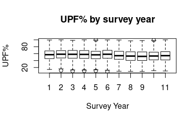

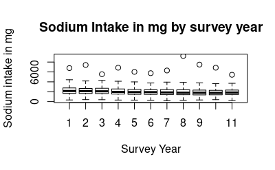

## 4.3 Outcome variable

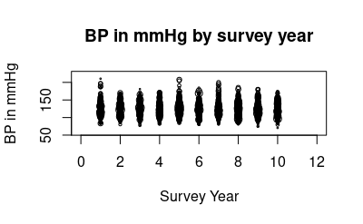

figure 6 shows that the mean BP is consistent across the waves.

## 4.4 Main Results

The main results are the correlation between the exposure and the outcome variables. Univariable regression demonstrates the interaction with other explanatory variables. Then multivariable regression is used. Mathematical models containing explanatory variables are constructed and compared using ‘goodness of fit’ statistics.

In the simplest model, by calculation using a Chi squared 2*2 table, the odds ratio for hypertension in participants exposed to UPF >63% is 0.5. The odds ratio for hypertension in participants exposed to Sodium >5000mg is 1.45. These results take no account of weighting, or confounding, but give an indication of the expected result.

Univariable regression is adjusted for weighted survey samples. Identified important relationships within the data. Confounding plays a part in these results.

UPF does show a negative relationship with BP, which is statistically significant, beta = -0.19 (CI -0.22,-0.15).

There is also a negative relationship for UPF with Age, again statistically significant beta = -0.25 (CI -0.26,-0.23).

Age has a relationship with BP with a statistically significant positive gradient beta= 0.43 (CI 0.41,0.45).

There is also a positive relationship with Sodium, which is also statistically significant 1.5 (CI 0.77,2.3).

Univariable Regression (NDNS data 2008-2019)

| Characteristic | BP Beta | BP 95% CI1 | BP p-value | UPF Beta | UPF 95% CI1 | UPF p-value | Sodium Beta | Sodium 95% CI1 | Sodium p-value |
| --- | --- | --- | --- | --- | --- | --- | --- | --- | --- |
| zPF | -0.19 | -0.22, -0.15 | <0.001 |  |  |  |  |  |  |
| Na | 0.00 | 0.00, 0.00 | <0.001 | 0.00 | 0.00, 0.00 | <0.001 |  |  |  |
| Age | 0.43 | 0.41, 0.45 | <0.001 | -0.25 | -0.26, -0.23 | <0.001 | 1.5 | 0.77, 2.3 | <0.001 |
| agegad3 |  |  |  |  |  |  |  |  |  |
| (0,18] | — | — |  | — | — |  | — | — |  |
| (18,35] | 11 | 9.6, 12 | <0.001 | -9.1 | -10, -8.0 | <0.001 | 540 | 485, 595 | <0.001 |
| (35,50] | 14 | 13, 15 | <0.001 | -13 | -14, -12 | <0.001 | 408 | 363, 454 | <0.001 |
| (50,65] | 22 | 20, 23 | <0.001 | -17 | -18, -16 | <0.001 | 250 | 204, 295 | <0.001 |
| (65,108] | 27 | 25, 29 | <0.001 | -14 | -15, -13 | <0.001 | 91 | 45, 138 | <0.001 |
| bmival | 1.0 | 0.92, 1.1 | <0.001 | -0.29 | -0.35, -0.23 | <0.001 | 17 | 14, 19 | <0.001 |
| IMD |  |  |  |  |  |  |  |  |  |
| Most deprived | — | — |  | — | — |  | — | — |  |
| 2 | 2.2 | 0.49, 4.0 | 0.012 | -1.6 | -3.0, -0.18 | 0.027 | 47 | -31, 126 | 0.2 |
| 3 | 2.3 | 0.69, 4.0 | 0.005 | -3.5 | -4.8, -2.1 | <0.001 | 77 | 2.0, 151 | 0.044 |
| 4 | 3.1 | 1.5, 4.8 | <0.001 | -4.2 | -5.6, -2.9 | <0.001 | 86 | 13, 159 | 0.021 |
| least deprived | 3.3 | 1.5, 5.0 | <0.001 | -5.3 | -6.6, -4.0 | <0.001 | 4.6 | -60, 69 | 0.9 |

1CI = Confidence Interval

Multivariable regression models were constructed. They are regressed against hypertension in patients who are not on BP reducing medication.

The model, “Sodium Only”, includes Sodium as the exposure variable. The odds ratio for the group taking between 5000mg and 6000mg per day is statistically significantly different from those taking less than 3000mg per day. There is an odds ratio of 5.20 (CI 1.39,19.5) for this group.

“UPF only” shows a significant difference in odds ratio 0.60(CI 0.36,0.99) for the group 63-80%.

The last model, “Sodium and UPF”, shows that when combined the effect remains. The odds ratio for 5000-6000mg of Sodium remains statistically significant 5.57(1.47,21.2). The odds ratio for UPF also remains 0.57(0.34,0.94). These are both changed from the separate models. The Akaike Information Criterion (AIC), a measure of ‘goodness of fit’, is lower for this combined model, 3590.81, indicating it is a better fit for the data also.

Table 4.5.1 follows below.

Table of multivariable regression against BP to identify the effects relating to Sodium and UPF NDNS data 2008-2019

| Characteristic | Sodium only OR1 | Sodium only 95% CI1 | Sodium only p-value | UPF only OR1 | UPF only 95% CI1 | UPF only p-value | Sodium and UPF OR1 | Sodium and UPF 95% CI1 | Sodium and UPF p-value |
| --- | --- | --- | --- | --- | --- | --- | --- | --- | --- |
| Sodium Intake mg |  |  |  |  |  |  |  |  |  |
| (0,1.5e+03] | — | — |  |  |  |  | — | — |  |
| (1.5e+03,3e+03] | 0.99 | 0.69, 1.44 | >0.9 |  |  |  | 1.05 | 0.72, 1.52 | 0.8 |
| (3e+03,5e+03] | 1.25 | 0.75, 2.09 | 0.4 |  |  |  | 1.38 | 0.82, 2.33 | 0.2 |
| (5e+03,6e+03] | 5.20 | 1.39, 19.5 | 0.015 |  |  |  | 5.57 | 1.47, 21.2 | 0.012 |
| (6e+03,1e+04] | 0.00 | 0.00, 0.00 | <0.001 |  |  |  | 0.00 | 0.00, 0.00 | <0.001 |
| UPF % |  |  |  |  |  |  |  |  |  |
| (0,33] |  |  |  | — | — |  | — | — |  |
| (33,45] |  |  |  | 0.86 | 0.54, 1.36 | 0.5 | 0.83 | 0.52, 1.32 | 0.4 |
| (45,63] |  |  |  | 0.73 | 0.48, 1.12 | 0.15 | 0.70 | 0.46, 1.08 | 0.11 |
| (63,80] |  |  |  | 0.60 | 0.36, 0.99 | 0.046 | 0.57 | 0.34, 0.94 | 0.029 |
| (80,100] |  |  |  | 0.74 | 0.27, 2.05 | 0.6 | 0.69 | 0.24, 1.94 | 0.5 |
| AIC | 3594.65 |  |  | 3598.17 |  |  | 3590.81 |  |  |

1OR = Odds Ratio, CI = Confidence Interval  
All models include additional variables Sex,Age, BMI, Education, IMD and Survey Year

### 4.4.1 Relative Effect Size calculation

Using the AIC statistic assessing goodness of fit for each model gives another way of understanding the comparative effects between variables. The lowest scored model is the optimal model. The ‘best’ of these models is “Sodium and UPF” AIC= 3590.81. The other models (Sodium only (AIC = 3594.65), and UPF only (AIC=3598.17)) both being further away from the lowest value.

The lower difference in values suggests the Sodium only model is the next best model. The UPF only value suggests that this is the least good model. That is the combined effect of UPF and Sodium is not the same as either of these separately.

Odds ratios also change in the combined model. This adds to the impression that the relationship between Sodium intake and UPF is not a simple one.

These relationships need to be viewed with caution as the values are intended to described ‘goodness of fit’ which is already an abstraction.

# 5 Discussion

## 5.1 Key Results

This analysis shows a statistically significant correlation between high Sodium intake and hypertension . There was an increased odds ratio of hypertension with higher Sodium intake (OR=5.57(1.47,21.2)). Between high UPF and hypertension there was a lower odds ratio of hypertension with high UPF intake (OR=0.57(0.34,0.94)). This is present in a combined multivariable logistic regression model which includes age, sex, BMI, IMD, age at leaving education, and survey year.

The effect is also present in the multivariable logistic regression model of each individual variable, for Sodium this is OR=5.20(CI 1.39,19.5), and for UPF OR=0.60(CI 0.36,0.99). These use the same explanatory variables.

The descriptive analysis does show the size of different groups. It also shows how they differ from the overall population. These factors are reasons for caution over the overall results.

Participants with high Sodium >5000mg are more likely to have hypertension. He (51) , Graudal (13) , Strazzullo (12) , inform us that high Sodium intake is contributing to high BP. However, causation cannot be identified in NDNS as it is cross-sectional.

Low UPF intake is correlated with high BP. Only correlation is certain, and ‘reverse correlation’ may be an issue. Wang (32) , Barbosa (8) , and Mambrini (9) all find a positive correlation using longitudinal studies such as those of Scaranni (37) and Mendonça (59) . The descriptive data shows that those with >63% UPF are a peculiar subgroup. They are different in age from those with high Sodium or high BP.

## 5.2 Limitations

The data is from a cross-sectional study, and so has the limitations of this design. Exposure and outcome are measured at the same time, so causal relationships can be confusing or reversed. This ‘reverse causation’ would be appropriate to describe the idea that the high UPF exposure is something which applies to young age groups and has not yet had time to have an effect. If older participants were not exposed when they were younger, their levels of BP would not be increased but instead represent a baseline measurement. This results in inverting the relationships in the values.Prospective and longitudinal studies, such as cohort or RCT studies do not have this issue.

This study was organised by government departments connected with food and farming alongside the Department of Health and is supervised by the Scientific Advisory Committee on Nutrition (SACN). The sample was designed to monitor relevant outputs not for in-depth subgroup analysis. It was powered for monitoring of food intake across the UK population. Funding and commissioning processes affect design structure and might also affect participant engagement and expectation.

#### 5.2.0.1 Age

Age is a particular feature in this outcome. BP is very strongly affected by age as is exposure to Sodium and UPF.

In cross sectional studies Age has several dimensions. Age identifies cohorts of people with particular experiences, it identifies duration of experience, it represents physiologically different states, and it also identifies access to resources financial, material, and experiential.

Prospective, longitudinal studies, and case matching can help reduce some of these effects. However longitudinal studies have reported similarly equivocal results, identifying a potentially more complex interaction.

### 5.2.1 Bias

Selection bias was approached by using random selection of participants using a carefully constructed stratification model. Addresses were selected by postal units to ensure geographic spread of participants. This ensured that whilst random the sample remained representative.

Uptake and Drop out bias was approached by ensuring that sample sizing included scope for this to enable comparable sample sizes across annual waves.

Social desirability bias acknowledges that participants remember and record intake framed by their beliefs about the needs of the study, and their beliefs about what is perceived as being healthy. To examine this in the first wave, Lennox et al (60) conducted a double labelled water study. They compared reported energy intake with measured values. They showed some significant differences between measured energy intake, and reported energy intake with differences between different age groups.

At the analysis stage weighting was used to standardise the sample for several variables. Those selected were age, sex, region and IMD. Weights are available for different levels of analysis.

The variables’ changes over the survey years after weighting were assessed to understand changes in sampling over the course of the study.

The result depends on participants recording foods in the same way as time goes on. Exposure of the whole population to a stimulus to change their diet or the recording of their diet may result in systematic changes in results.

In years 9-11 a slight difference for identifying foods for analysis as researchers have started to become aware of the need to understand ‘processing’. This may account for the apparent lower exposure in the last three years.

Changes might affect the outcome variable less, though, BP measurement technology has changed over ten years. BP machines derive their results from the changes in pressure detected in the arm of the participant, the algorithm used by the sphygmomanometer may have changed.

Subgroup analysis overcomes careful sample selection and stratification reintroducing bias. Selection for BP, UPF or Sodium changes the cohort sex balance, age range and IMD pattern. Future studies will consider these at the planning stage to introduce sampling methods to avoid this bias.

## 5.3 Interpretation

This research intended to find out if a policy of improving diet might reduce the risk of non-communicable disease specifically by reducing BP.

In trying to introduce public health policy it is important to be guided by evidence, and also to be aware of real world influences which affect policy delivery, outputs and outcomes. Positivist science needs to be integrated with social, economic and political aspects to deliver solutions.

This research agrees that Monteiro’s model (5) might complement the established nutritional model. It is a model which is a macro level description, and explains the situation epidemiologically. Other models have subsequently taken more of this approach Martinez-Perez (46) examined the relative merits of the models.

[output not shown]

### 5.3.1 Policy in public health

From a population level there are clear indicators that high level factors have effects. Whitehead and Dahlgren’s (21) rainbow of social determinants of health is a model which explains the highest level population effects. Diderichson’s (61) explanation of the differential expression of effects identifies targets for policy intervention.

Marmot’s model (62) (22), like Healthy Cities (63) previously, identifies a set of policies for Diderichson’s policy points to enable improvement at a political and civic level. These are all at a high level and remain largely theoretical until given specific examples such as Katikireddi showed for Covid-19 (64).

Dimbleby’s Food system (65) thinking is an example which fits an example within these civic structures. It is a way of tying these high level systems approaches to more specific realisable actions. It helps to tell us what can be done and how to do it.

### 5.3.2 Theorizing Food

Food in biological terms is fuel, and raw materials for bodily processes. It is sometimes toxic, and then needs careful handling. However, for every person there is a relationship with food which combines these biological aspects with likes and dislikes, ‘like apple pie’, ‘a land of milk and honey’ . These are based on aesthetic considerations. There are memories, special occasions, and cultural events which describe our food. Each of these appears personal and individual. These are cultural considerations. There are menus and recipes, restaurants, chefs and cooks as well as supermarkets, producers all part of the economic facet of food.

Martinez (66) posits a theoretical epistemology of food with three key aspects, the biological, the economic, and the cultural. In this theory we can explain that lack of food is not just a lack of fuel or building material, it is social isolation and cultural isolation, it is about economic deprivation. This model has the benefit of simplicity, but must be interpreted flexibly to understand how it can be best used.

Austerity has identified the economic background to food economics. Barr (67) has described the socio-biologic effect of this policy. Bordieu’s (68) constructionist model of the sociology of food would fit into the cultural domain, but with some economic aspects.

Monteiro, and similar systems IARC, UNC, IFIC, seem to fit in with this more complex theory of food. ‘Processing’ might include biological addition and subtraction of chemicals which affect satiety, or the gut biome, in which case we remain in the biologic. Even theories which consider the ‘food matrix’ as the whole food being more than the sum of its parts retain a biology preference.

Other theories around UPF though move into the economic. These include those which identify the economics of UPF, the cheaper production or transport cost, the greater profits, the ease of access, the reduced need for skills or equipment, or time to deliver ‘meals’.

The cultural aspects of the nutrition transition relate to changes in the family and home. Gender issues around mother, and wife roles being altered. This occurs because UPF makes it possible, but then makes UPF more inevitable due to changes to arrangements for meals,equipment, resources and skills.

### 5.3.3

Food System, Regulation Politics and Economics

The mid operational level is where systems thinking enables construction of a socially and politically aware system. Dimbleby’s government report took into account the important realities of political deliverability, but this was not enough for to persuade at this time. His book (69) adds a publicly accessible layer to the report, and disseminates the ideas to a broader audience.

The picture is largely that of the economics of production, and distribution are affected by a market which lacks appropriate regulation. This results in malfunctioning at many levels. This damages all participants, producers, distributors, regulators, and the public.

He also describes a future of engineered food. Without regulation this will be a dystopia leading to a need for significant health intervention to balance the harms done.

In his complementary description, Tulleken (70) concentrates on how UPF is a part of this food economic system. In his account the lack of safety regulation enables a natural economic process of deterioration of the quality of food. UPF is simply the expected result of producers not having to demonstrate the safety of the additives they use. This leads to progressive deterioration of the quality of products. These cease to be nutritious and are simply units of financial exchange.

Both of these take the idea that UPF is an economic and biological description of food as central to their model of the real world.

The ‘nutrition transition’ is an economic and cultural concept. Colombet’s (71) identification of UPF use with socio-economic status in developing economies situates the UPF concept across these domains. That UPF is more predominant in families with more poverty clearly makes the economic case. The cultural case relates to how this changes family activities, interactions, and choices.

The idea that the nutrition transition (72) occurs in relation to industrialisation, or to more women working outside of the home links UPF to feminism and power relations inside and around families.

### 5.3.4 Explanatory mechanisms and Reformulation

Many studies have looked at how individuals respond to the challenges of UPF. These take approaches which are sometimes closer to individuals and sometimes further away.

They look at individual disorders, and collections of disorders

They look at biological, socioeconomic and cultural mechanisms. This research follows those which have looked at BP, and follows those who have used NDNS.

Reformulation is a policy suggestion which is partly at this level and partly about the biological /physiological level. Reformulation is a policy suggestion, where UPF is further processed to remove the salt.

By demonstrating that UPF is not just high in salt this research supports the argument that further formulation may not be effective policy for reducing BP. Pearson-Stuttard et al (73) model the effects of salt reformulation, and identify economic and social benefits. Including negative effects of UPF that might not be due to salt, which might improve their model.

### 5.3.5 BP mechanisms Is it Sodium?

At the individual level of physiological mechanisms BP seems to be a measurable outcome.

**BP** is not so simple though. It has been studied for some time. There are competing or possibly contributory mechanisms.

**UPF and BP** Study is still early for this concept. Notwithstanding a recent flurry of publicity. there is not a large literature. There is little consistency in approach. Much of the work relies on already collected data. There are few papers and they are difficult to compare.

**This research tests one assumption**. That high UPF intake leads to high salt intake and so to hypertension. This would appear to be a positivist assumption, tested using quantitative methods.

The interpretation of the results is that this is not as simple as assumed.

This research shows that UPF and Sodium have different effect sizes and that combining them in one model results in an effect which is not replacement, addition or subtraction.

### 5.3.6 High UPF intake

Mertens (74) identifies that the UK has one of the highest % intake of UPF in Europe. The USA, Canada and Australia have similarly high levels. Other European countries are still fighting to retain a different food culture, Touvier et al with Nutrinet (75) (76) .

Colombet (71) highlights countries in the rest of the world at differing levels of ‘nutrition transition’, where increasing amounts of the diet comes from UPF instead of traditional diets. This might be influenced by the degree of ‘westernisation’/‘internationalization’/ or ‘capitalist colonialisation’ into local culture, as well as by more general socio-economic factors (77) .

### 5.3.8 A synergistic effect

The regression model including both exposure variables had a better fit of data than either individually. This finding suggests that the effect of each variable is not the whole effect, but that there is a synergistic effect. This would fit with the idea that Monteiro’s concept of UPF (5) is wider than being simply a nutritional effect.

This effect might be due to broader biologic effects. These might be presence or absence of other chemicals, structural ‘food matrix’ effects, or energy density as Rauber explains (80) . Alternatively, it could relate to the wider economic and cultural aspects of UPF.

### 5.3.9 Ideas for further research

Further research based on the findings is needed for confirmation by further review and analysis. The finding of a synergistic effect, and to understand the types of UPF ingested in this population would be priorities.

This further study might also include attempts to better map Martinez’s putative epistemological framework. This could be by looking quantitatively for more specific economic and cultural markers in the data. Qualitative approaches might also be engaged, perhaps in a mixed methods approach to identify the importance of the findings to real populations in a local context.

#### 5.3.9.1 Public Health Policy ideas

This study aims to inform local policy to reduce BP and so Non-Communicable Disease. If UPF and Sodium intake increase the risk of hypertension then policy to reduce exposure might deliver change at a population level. This study supports the case for a place based food strategy approach such as in Liverpool (16) .

Dietary approaches to improving public health are able to deliver proportionate and universal interventions to populations to reduce the incidence of non- communicable disease (NCD). When delivered up stream at the policy level they are effective and efficient and minimise cost. These approaches offer significant benefits over actions targeted at individuals.

Dietary and ‘awareness’ approaches can be used by individuals. These approaches risk the development of a culture of blame of individuals and of sub-groups in society.

## 5.4 Generalisability

Caution is in order when extrapolating down to local areas from national data. Age and sex standardisation might make the datasets more similar. IMD differences are harder to control.

# 6 Conclusion

In summary,

In this representative sample of adults and children across the four home nations of the UK between 2008 and 2019, exposure to higher Sodium dietary intake, and lower UPF dietary intake, increased the odds of having a mean systolic blood pressure of over 140mmHg.

Combining the two exposures had a larger than expected effect on the ‘goodness of fit’ of the model. This suggests a broader effect than nutrition alone, possibly measuring some of the economic and cultural aspects of UPF.

### 6.0.1 Further Recommendations

Further quantitative and qualitative research will be needed to understand this result.

A strategic approach to food policy might be needed, independent of reformulation.

# 7 Bibliography

# 8 Appendix 1 Approved Proposal

# 9 Appendix 2 Ethics Certificate

# 10 Appendix 3 Software used

The software used

CRAN

GT Summary (81)

1.

Cardiovascular disease - data - OHID [Internet]. Available from: https://fingertips.phe.org.uk/profile/cardiovascular/data#page/1/gid/1938133106/pat/223/par/E40000010/ati/221/are/nE54000008/iid/219/age/1/sex/4/cat/-1/ctp/-1/yrr/1/cid/4/tbm/1/page-options/car-do-0

2.

High Blood Pressure & Cardiovascular Disease Prevention | Champs Public Health Collaborative [Internet]. 2020. Available from: https://champspublichealth.com/blood-pressure/

3.

Rang HP, Dale MM. Pharmacology. Edinburgh ; New York: Churchill Livingstone; 1987.

4.

Monteiro CA. Nutrition and health. The issue is not food, nor nutrients, so much as processing. Public Health Nutrition [Internet]. 2009 May;12(5):729–31. Available from: https://www.cambridge.org/core/journals/public-health-nutrition/article/nutrition-and-health-the-issue-is-not-food-nor-nutrients-so-much-as-processing/0C514FC9DB264538F83D5D34A81BB10A

5.

Monteiro CA, Levy RB, Claro RM, Castro IRR de, Cannon G. A new classification of foods based on the extent and purpose of their processing. Cadernos de Saúde Pública [Internet]. 2010 Nov;26:2039–49. Available from: http://www.scielo.br/j/csp/a/fQWy8tBbJkMFhGq6gPzsGkb/?lang=en

6.

Du S, Neiman A, Batis C, Wang H, Zhang B, Zhang J, et al. Understanding the patterns and trends of sodium intake, potassium intake, and sodium to potassium ratio and their effect on hypertension in China1,2,3. The American Journal of Clinical Nutrition [Internet]. 2014 Feb 1;99(2):334–43. Available from: https://www.sciencedirect.com/science/article/pii/S0002916523049511

7.

Wang M, Du X, Huang W, Xu Y. Ultra-processed Foods Consumption Increases the Risk of Hypertension in Adults: A Systematic Review and Meta-analysis. American journal of hypertension. 2022;35(10):892–901.

8.

Barbosa SS, Sousa LCM, Oliveira Silva DF de, Pimentel JB, Evangelista KCM de S, Lyra C de O, et al. A systematic review on processed/ultra-processed foods and arterial hypertension in adults and older people. Nutrients [Internet]. 2022 Mar 13;14(6):1215. Available from: https://www.ncbi.nlm.nih.gov/pmc/articles/PMC8955286/

9.

Mambrini SP, Menichetti F, Ravella S, Pellizzari M, De Amicis R, Foppiani A, et al. [Ultra-processed food consumption and incidence of obesity and cardiometabolic risk factors in adults: A systematic review of prospective studies](https://doi.org/10.3390/nu15112583). Nutrients. 2023;15(11):2583.

10.

Cappuccio FP, Capewell S. Facts, Issues, and Controversies in Salt Reduction for the Prevention of Cardiovascular Disease. 2015;7(1):21.

11.

He FJ, MacGregor GA. Reducing Population Salt Intake Worldwide: From Evidence to Implementation. Progress in Cardiovascular Diseases [Internet]. 2010 Mar 1;52(5):363–82. Available from: https://www.sciencedirect.com/science/article/pii/S0033062009001273

12.

Strazzullo P, D’Elia L, Kandala NB, Cappuccio FP. [Salt intake, stroke, and cardiovascular disease: Meta-analysis of prospective studies](https://doi.org/10.1136/bmj.b4567). BMJ. 2009;339(7733):1296–b4567.

13.

Graudal N, Jürgens G, Baslund B, Alderman MH. [Compared with usual sodium intake, low- and excessive-sodium diets are associated with increased mortality: A meta-analysis](https://doi.org/10.1093/ajh/hpu028). American journal of hypertension. 2014;27(9):1129–37.

14.

Ma Y, He FJ, Sun Q, Yuan C, Kieneker LM, Curhan GC, et al. [24-hour urinary sodium and potassium excretion and cardiovascular risk](https://doi.org/10.1056/NEJMoa2109794). The New England journal of medicine. 2022;386(3):252–63.

15.

Moreira PVL, Baraldi LG, Moubarac JC, Monteiro CA, Newton A, Capewell S, et al. Comparing Different Policy Scenarios to Reduce the Consumption of Ultra-Processed Foods in UK: Impact on Cardiovascular Disease Mortality Using a Modelling Approach. Hernandez AV, editor. PLOS ONE [Internet]. 2015 Feb 13;10(2):e0118353. Available from: https://dx.plos.org/10.1371/journal.pone.0118353

16.

Liverpool healthy weight strategy 2018-2028. 2018; Available from: https://liverpool.gov.uk/media/1357254/2018-liverpool-healthy-weight-strategy_final.pdf

17.

Byker Shanks C, Vanderwood K, Grocke M, Johnson N, Larison L, Wytcherley B, et al. The UnProcessed pantry project (UP3): A community-based intervention aimed to reduce ultra-processed food intake among food pantry clients. Family & Community Health [Internet]. 2022 Mar;45(1):23. Available from: https://journals.lww.com/familyandcommunityhealth/Abstract/2022/01000/The_UnProcessed_Pantry_Project__UP3___A.3.aspx

18.

University Of Cambridge MEU, NatCen Social Research. NDNS RPNational diet and nutrition SurveysNational diet and nutrition survey years 1-11, 2008-2019. 2022; Available from: https://beta.ukdataservice.ac.uk/datacatalogue/doi/?id=6533#19

19.

Elm E von, Altman DG, Egger M, Pocock SJ, Gøtzsche PC, Vandenbroucke JP. Strengthening the reporting of observational studies in epidemiology (STROBE) statement: guidelines for reporting observational studies. BMJ [Internet]. 2007 Oct 18;335(7624):806–8. Available from: https://www.bmj.com/content/335/7624/806

20.

Dahlgren G, Whitehead M. The Dahlgren-Whitehead model of health determinants: 30 years on and still chasing rainbows. Public Health [Internet]. 2021 Oct 1;199:20–4. Available from: https://www.sciencedirect.com/science/article/pii/S003335062100336X

21.

Dahlgreen G, Whitehead M. European strategies for tackling social inequities in health: Levelling up Part 2. WHO Regional Office for Europe. 2007;149.

22.

Marmot M, Allen J, Boyce T, Goldblatt P, Callaghan O. All together fairer: Health equity and the social determinants of health in cheshire and merseyside. London; 2022.

23.

Jafar AJN. What is positionality and should it be expressed in quantitative studies? Emergency Medicine Journal [Internet]. 2018 Jan 11; Available from: https://emj.bmj.com/lookup/doi/10.1136/emermed-2017-207158

24.

Illich I. Limits to medicine: Medical nemesis : The expropriation of health. London: Penguin Books; 1990.

25.

Foucault M, Sheridan A. The birth of the clinic an archaeology of medical perception. London; New York: Routledge; 2003.

26.

Evans L, Trotter DRM. Epistemology and Uncertainty in Primary Care: An Exploratory Study. Family Medicine. 41(5):8.

27.

Page MJ, Moher D, Bossuyt PM, Boutron I, Hoffmann TC, Mulrow CD, et al. PRISMA 2020 explanation and elaboration: updated guidance and exemplars for reporting systematic reviews. BMJ [Internet]. 2021 Mar 29;n160. Available from: https://www.bmj.com/lookup/doi/10.1136/bmj.n160

28.

Scopus | the largest database of peer-reviewed literature | elsevier [Internet]. Available from: https://www.elsevier.com/en-gb/solutions/scopus

29.

Ovid: Search form [Internet]. Available from: https://ovidsp.dc1.ovid.com/ovid-b/ovidweb.cgi?QS2=434f4e1a73d37e8cf66185f15d893d09240dc867c99b537069b551c04268…

30.

SACN statement on processed foods and health.

31.

Barbosa LB, Vasconcelos NBR, Dos Santos EA, Dos Santos TR, Ataide-Silva T, Ferreira H da S. [Ultra-processed food consumption and metabolic syndrome: A cross-sectional study in quilombola communities of alagoas, brazil.](https://doi.org/10.1186/s12939-022-01816-z) International journal for equity in health. 2023;22(1):14.

32.

Wang L, Du M, Wang K, Khandpur N, Rossato SL, Drouin-Chartier JP, et al. Association of ultra-processed food consumption with colorectal cancer risk among men and women: Results from three prospective US cohort studies. BMJ [Internet]. 2022 Aug 31 [cited 2022 Dec 1];378:e068921. Available from: https://www.bmj.com/content/378/bmj-2021-068921

33.

D’Elia L, Galletti F, La Fata E, Sabino P, Strazzullo P. [Effect of dietary sodium restriction on arterial stiffness: Systematic review and meta-analysis of the randomized controlled trials](https://doi.org/10.1097/HJH.0000000000001604). Journal of hypertension. 2018;36(4):734–43.

34.

Leyvraz M, Chatelan A, Costa BR da, Taffé P, Paradis G, Bovet P, et al. [Sodium intake and blood pressure in children and adolescents: A systematic review and meta-analysis of experimental and observational studies](https://doi.org/10.1093/ije/dyy121). International journal of epidemiology. 2018;47(6):1796–810.

35.

Frías JRG, Cadena LH, Villarreal AB, Piña BGB, Mejía MC, Cerros LAD, et al. [Effect of ultra-processed food intake on metabolic syndrome components and body fat in children and adolescents: A systematic review based on cohort studies](https://doi.org/10.1016/j.nut.2023.112038). Nutrition (Burbank, Los Angeles County, Calif). 2023;111:112038–8.

36.

Monge A, Silva Canella D, López-Olmedo N, Lajous M, Cortés-Valencia A, Stern D. [Ultraprocessed beverages and processed meats increase the incidence of hypertension in mexican women](https://doi.org/10.1017/S0007114520004432). British journal of nutrition. 2021;126(4):600–11.

37.

Scaranni P de O da S, Cardoso L de O, Chor D, Melo ECP, Matos SMA, Giatti L, et al. Ultra-processed foods, changes in blood pressure and incidence of hypertension: The Brazilian Longitudinal Study of Adult Health (ELSA-Brasil). Public health nutrition. 2021;24(11):3352–60.

38.

De Deus Mendonça R, Souza Lopes AC, Pimenta AM, Gea A, Martinez-Gonzalez MA, Bes-Rastrollo M. Ultra-processed food consumption and the incidence of hypertension in a mediterranean cohort: The seguimiento universidad de navarra project. American journal of hypertension. 2017;30(4):358–66.

39.

Ivancovsky-Wajcman D, Fliss-Isakov N, Webb M, Bentov I, Shibolet O, Kariv R, et al. Ultra-processed food is associated with features of metabolic syndrome and non-alcoholic fatty liver disease. Liver international. 2021;41(11):2635–45.

40.

Lavigne-Robichaud M, Moubarac JC, Lantagne-Lopez S, Johnson-Down L, Batal M, Laouan Sidi EA, et al. Diet quality indices in relation to metabolic syndrome in an Indigenous Cree (Eeyouch) population in northern Québec, Canada. Public health nutrition. 2018;21(1):172–80.

41.

Martinez Steele E, Marrón Ponce JA, Cediel G, Louzada MLC, Khandpur N, Machado P, et al. [Potential reductions in ultra-processed food consumption substantially improve population cardiometabolic-related dietary nutrient profiles in eight countries](https://doi.org/10.1016/j.numecd.2022.08.018). Nutrition, metabolism, and cardiovascular diseases. 2022;32(12):2739–50.

42.

Nardocci M, Polsky JY, Moubarac JC. Consumption of ultra-processed foods is associated with obesity, diabetes and hypertension in Canadian adults. Canadian Journal of Public Health [Internet]. 2021;112(3):421–9. Available from: https://link.springer.com/10.17269/s41997-020-00429-9

43.

Nasreddine L, Tamim H, Itani L, Nasrallah MP, Isma’eel H, Nakhoul NF, et al. A minimally processed dietary pattern is associated with lower odds of metabolic syndrome among Lebanese adults. Public health nutrition. 2018;21(1):160–71.

44.

Rezende-Alves K, Hermsdorff HHM, Miranda AE da S, Lopes ACS, Bressan J, Pimenta AM. Food processing and risk of hypertension: Cohort of Universities of Minas Gerais, Brazil (CUME Project). Public Health Nutrition [Internet]. 2021 Sep;24(13):4071–9. Available from: http://www.cambridge.org/core/journals/public-health-nutrition/article/food-processing-and-risk-of-hypertension-cohort-of-universities-of-minas-gerais-brazil-cume-project/100DC0D407DBEAAA99C701A707061329

45.

Da Conceição AR, De Almeida Fonseca PC, De Castro Morais D, De Souza ECG. Association of the degree of food processing with the consumption of nutrients and blood pressure. Mundo da Saude [Internet]. 2019;43(2):512–29. Available from: https://www.scopus.com/inward/record.uri?eid=2-s2.0-85070201239&doi=10.15343%2f0104-7809.20194302512529&partnerID=40&md5=51c0ed3185c1706986c72dd059eb1111

46.

Martinez-Perez C, San-Cristobal R, Guallar-Castillon P, Martínez-González MÁ, Salas-Salvadó J, Corella D, et al. Use of Different Food Classification Systems to Assess the Association between Ultra-Processed Food Consumption and Cardiometabolic Health in an Elderly Population with Metabolic Syndrome (PREDIMED-Plus Cohort). Nutrients [Internet]. 2021 Jul 20;13(7):2471. Available from: https://www.mdpi.com/2072-6643/13/7/2471

47.

Martinez-Steele E, Khandpur N, Batis C, Bes-Rastrollo M, Bonaccio M, Cediel G, et al. Best practices for applying the nova food classification system | nature food. Nature Food [Internet]. 2023 Jan 6; Available from: https://www.nature.com/articles/s43016-023-00779-w

48.

Smiljanec K, Mbakwe AU, Ramos-Gonzalez M, Mesbah C, Lennon SL. Associations of Ultra-Processed and Unprocessed/Minimally Processed Food Consumption with Peripheral and Central Hemodynamics and Arterial Stiffness in Young Healthy Adults. Nutrients [Internet]. 2020 Nov;12(11). Available from: https://www.ncbi.nlm.nih.gov/pmc/articles/PMC7690393/

49.

Shim SY, Kim HC, Shim JS. [Consumption of Ultra-Processed Food and Blood Pressure in Korean Adults](https://doi.org/10.4070/kcj.2021.0228). Korean Circ J. 2022 Jan;52(1):60–70.

50.

Shim SY, Kim HC, Shim JS. Consumption of ultra-processed food and blood pressure in korean adults. Korean circulation journal. 2022;52(1):60–70.

51.

He FJ, MacGregor GA. Effect of modest salt reduction on blood pressure: A meta-analysis of randomized trials. Implications for public health. J hum hypertens 2002;16:761-70.

52.

Bruce N, Pope D, Stanistreet D. Quantitative methods for health research: A practical interactive guide to epidemiology and statistics. Second edition. Hoboken, NJ: Wiley; 2018.

53.

Wang M, Du X, Huang W, Xu Y. Ultra-processed foods consumption increases the risk of hypertension in adults: A systematic review and meta-analysis. American journal of hypertension. 2022;35(10):892–901.

54.

Criado-Perez C. Invisible women: Exposing data bias in a world designed for men. London: Vintage; 2020. 411 p.

55.

OpenEpi. OpenEpi - sample size for unmatched case-control studies [Internet]. 2021. Available from: https://www.openepi.com/SampleSize/SSCC.htm

56.

Wang M, Du X, Huang W, Xu Y. Ultra-Processed Foods Consumption Increases the Risk of Hypertension in Adults: A Systematic Review and Meta-Analysis. American Journal of Hypertension [Internet]. 2022 Oct 1 [cited 2022 Nov 12];35(10):892–901. Available from: https://doi.org/10.1093/ajh/hpac069

57.

R Core Team. R: A language and environment for statistical computing [Internet]. Vienna, Austria: R Foundation for Statistical Computing; 2022. Available from: https://www.R-project.org/

58.

Lumley T. Analysis of complex survey samples. Journal of Statistical Software. 2004;9(1):1–19.

59.

Deus Mendonca R de, Lopes ACS, Pimenta AM, Gea A, Martinez-Gonzalez MA, Bes-Rastrollo M. [Ultra-processed food consumption and the incidence of hypertension in a mediterranean cohort: The seguimiento universidad de navarra project.](https://doi.org/10.1093/ajh/hpw137) American journal of hypertension. 2017;30(4):358366.

60.

Lennox A, Bluck L, Page P, Pell D, Cole D, Steer T, et al. Misreporting in the National Diet and Nutrition Survey Rolling Programme (NDNS RP): summary of results and their interpretation.

61.

Diderichsen F, Hallqvist J, Whitehead M. Differential vulnerability and susceptibility: How to make use of recent development in our understanding of mediation and interaction to tackle health inequalities. International Journal of Epidemiology [Internet]. 2019 Feb 1;48(1):268–74. Available from: https://doi.org/10.1093/ije/dyy167

62.

Marmot M. Fair Society Healthy Lives (The Marmot Review) [Internet]. 2010. Available from: https://www.instituteofhealthequity.org/resources-reports/fair-society-healthy-lives-the-marmot-review

63.

Leeuw E de de, Simos J, editors. Healthy cities: the theory, policy, and practice of value-based urban planning. New York, NY: Springer; 2017.

64.

Katikireddi SV, Lal S, Carrol ED, Niedzwiedz CL, Khunti K, Dundas R, et al. Unequal impact of the COVID-19 crisis on minority ethnic groups: a framework for understanding and addressing inequalities. J Epidemiol Community Health [Internet]. 2021 Oct 1;75(10):970–4. Available from: https://jech.bmj.com/content/75/10/970

65.

Dimbleby H. The national food strategy - the plan [Internet]. Available from: https://www.nationalfoodstrategy.org/

66.

Martínez J. Epistemology of a New Era of Healthy Foods and the Construction of Social Myths. International Journal of Clinical Nutrition & Dietetics [Internet]. 2021 Oct 2;7(1). Available from: https://www.graphyonline.com/archives/IJCND/2021/IJCND-158/

67.

Barr B, Bambra C, Whitehead M. The impact of NHS resource allocation policy on health inequalities in england 2001-11 : : Longitudinal ecological study [Internet]. 2014. Available from: https://web.archive.org/web/http://www.bmj.com/content/348/bmj.g3231

68.

Bourdieu P, Bourdieu P. Distinction: a social critique of the judgement of taste. 11. print. Cambridge, Mass: Harvard Univ. Press; 2002.

69.

Dimbleby H. Ravenous how to get ourselves and our planet into shape. Great Britain: Profile Books; 2023.

70.

Tulleken C van. Ultra-processed people: why do we all eat stuff that isn’t food ... and why can’t we stop? London: Cornerstone Press; 2023.

71.

Colombet Z, Simioni M, Drogue S, Lamani V, Perignon M, Martin-Prevel Y, et al. Demographic and socio-economic shifts partly explain the Martinican nutrition transition: an analysis of 10-year health and dietary changes (20032013) using decomposition models. Public health nutrition. 2021;24(18):6323–34.

72.

Popkin BM, Ng SW. The nutrition transition to a stage of high obesity and noncommunicable disease prevalence dominated by ultra-processed foods is not inevitable. Obesity Reviews [Internet]. 2022;23(1). Available from: https://onlinelibrary.wiley.com/doi/10.1111/obr.13366

73.

Pearson-Stuttard J, Kypridemos C, Collins B, Mozaffarian D, Huang Y, Bandosz P, et al. [Estimating the health and economic effects of the proposed US food and drug administration voluntary sodium reformulation: Microsimulation cost-effectiveness analysis.](https://doi.org/10.1371/journal.pmed.1002551) PLoS medicine. 2018;15(4):e1002551.

74.

Mertens E, Colizzi C, Peñalvo JL. Ultra-processed food consumption in adults across europe. European Journal of Nutrition [Internet]. 2022;61(3):1521–39. Available from: https://www.ncbi.nlm.nih.gov/pmc/articles/PMC8921104/

75.

Srour B, Fezeu LK, Kesse-Guyot E, Allès B, Méjean C, Andrianasolo RM, et al. [Ultra-processed food intake and risk of cardiovascular disease: Prospective cohort study (NutriNet-santé)](https://doi.org/10.1136/bmj.l1451). BMJ. 2019;365(365):l1451–1.

76.

Touvier M. [Ultra-processed/ultra-formulated foods: Association with chronic disease risk](https://doi.org/10.1093/eurpub/ckaa165.1406). European journal of public health. 2020;30(Supplement_5).

77.

Colombet Z, Schwaller E, Head A, Kypridemos C, Capewell S, O’Flaherty M. OP12 Social inequalities in ultra-processed food intakes in the United Kingdom: A time trend analysis (20082018). J Epidemiol Community Health [Internet]. 2022 Aug 1;76(Suppl 1):A6–7. Available from: https://jech.bmj.com/content/76/Suppl_1/A6.2

78.

Webster JL, Dunford EK, Neal BC. [A systematic survey of the sodium contents of processed foods](https://doi.org/10.3945/ajcn.2009.28688). Am J Clin Nutr. 2010 Feb;91(2):413–20.

79.

Ni Mhurchu C, Capelin C, Dunford EK, Webster JL, Neal BC, Jebb SA. [Sodium content of processed foods in the United Kingdom: analysis of 44,000 foods purchased by 21,000 households](https://doi.org/10.3945/ajcn.110.004481). The American Journal of Clinical Nutrition. 2011 Mar;93(3):594–600.

80.

Rauber F, Steele EM, Louzada ML da C, Millett C, Monteiro CA, Levy RB. Ultra-processed food consumption and indicators of obesity in the United Kingdom population (2008-2016). PLOS ONE [Internet]. 2020 May 1;15(5):e0232676. Available from: https://journals.plos.org/plosone/article?id=10.1371/journal.pone.0232676

81.

Sjoberg DD, Whiting K, Curry M, Lavery JA, Larmarange J. Reproducible summary tables with the gtsummary package. The R Journal [Internet]. 2021;13:570–80. Available from: https://doi.org/10.32614/RJ-2021-053